# Linear regression

## Introduction

- Motivation
  - Why we need linear regression?
- Model assumptions
  - **Linearity**
  - **Independence**
  - **Homoscedasticity**
  - **Normality of residuals**
- Perform simple and multiple linear regression analysis
- Model diagnostics

## Motivation

Linear regression allows us to:

- Quantify the **effect** of one variable (e.g., age) on another (e.g., blood pressure)
- Make **predictions** for new individuals
- Control for other variables (e.g., age *and* sex *and* BMI)
- Evaluate **statistical significance** (is the effect real or due to chance?)

## Model assumptions

To make valid inferences from a linear regression (e.g., p-values, confidence intervals), certain **assumptions must be met**. Let’s go over each.

- **Linearity**:

  The relationship between the independent variable(s) and the dependent variable is **linear**.

  **Check with a scatterplot**: If the pattern is curved or non-linear → linear regression isn’t appropriate without transformation.
- **Independence**: Each observation must be statistically independent of the others.

  No repeated measurements on the same subject (unless modeled correctly)

  No clusters or related subjects (e.g., twins, families) unless accounted for
- **Homoscedasticity**: The variance of residuals (errors) should be the same across all levels of X.

  Plot residuals vs. fitted values.
- **Normality of residuals:** The residuals (errors) should be approximately normally distributed.

  Plot a histogram or Q–Q plot of residuals

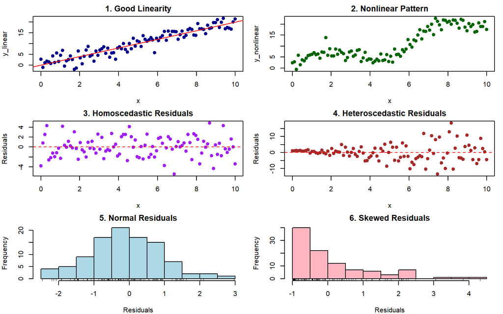

## Data example

We will use the same data, **fev**, used in the lecture ‘06_TestsOnMeans’. This data have `fev` measuring lung function in children who are smokers or non-smokers. Smoking tends to impair lung function.

- Important variables we use in this lecture:
  - **sex**: subject gender (1 = male, 2 = female)
  - **smoke**: smoke smoking habits (1 = yes, 2 = no)

```r
#fev=read.csv("./data/fev.csv",header=TRUE,row.names=1)
fev <- read.csv("https://raw.githubusercontent.com/couthcommander/sip_computing/main/labs/fev.csv",header=TRUE,row.names=1)
fev$sex=ifelse(fev$sex==1,"male","female")
fev$smoke=ifelse(fev$smoke==1,"yes","no")

head(fev)
```

```
##   age   fev height    sex smoke
## 1   9 1.708   57.0 female    no
## 2   8 1.724   67.5 female    no
## 3   7 1.720   54.5 female    no
## 4   9 1.558   53.0   male    no
## 5   9 1.895   57.0   male    no
## 6   8 2.336   61.0 female    no
```

## Simple linear regression

**Question**: Does age associated with fev (lung function )?

### Checking assumptions

**Normality**: Does the dependent variable follows a normal distribution?

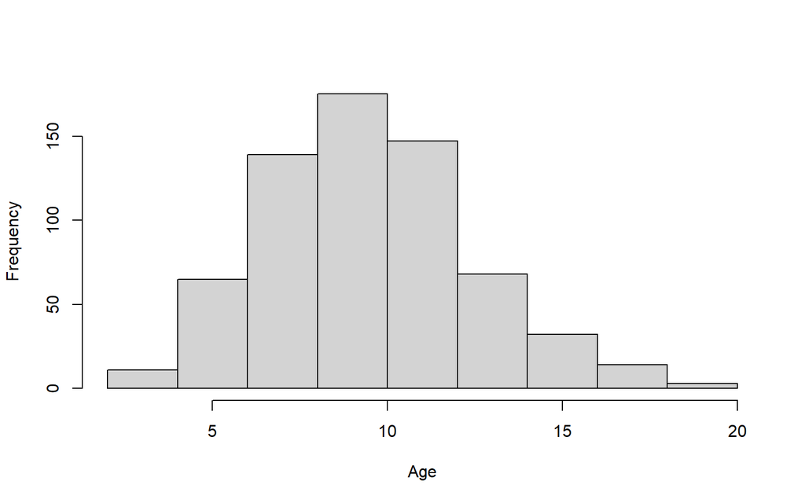

```r
hist(fev$age, main="", xlab="Age")
```

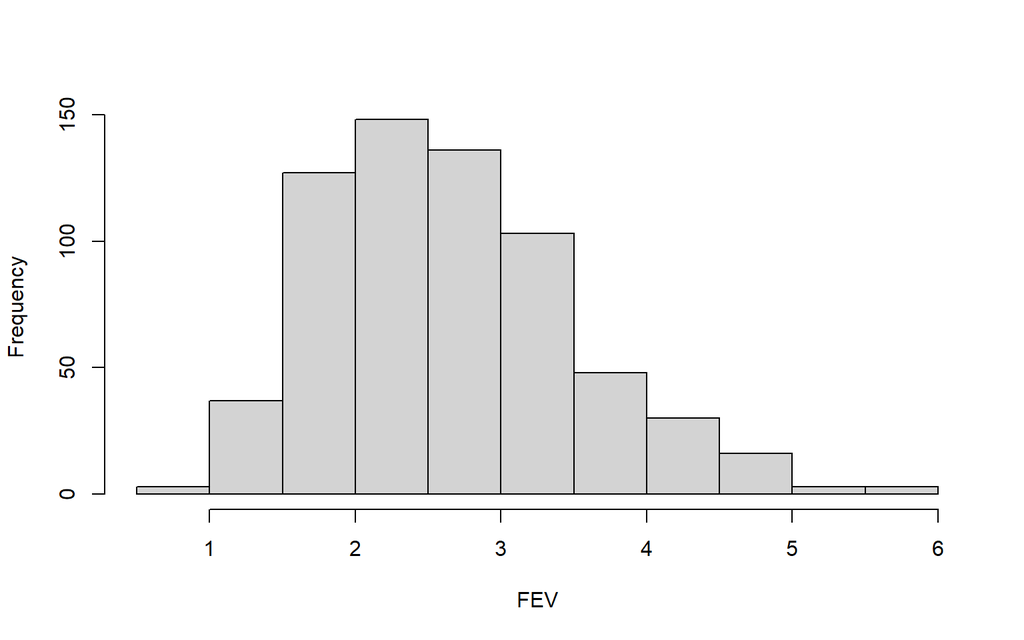

```r
hist(fev$fev, main="", xlab="FEV")
```

**Linearity**: Does the relationship between the independent variable and the dependent variable is linear?

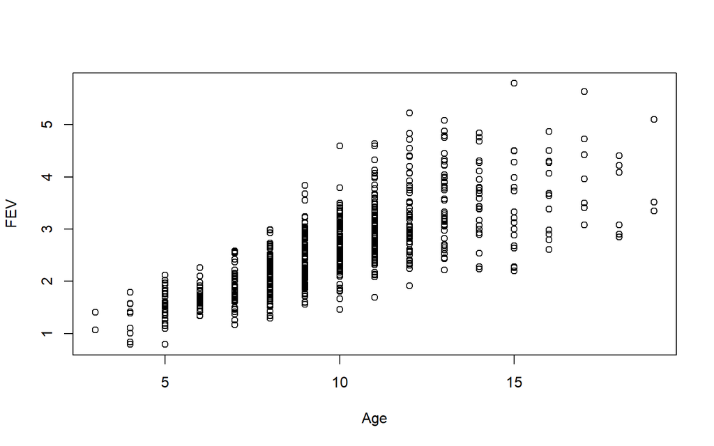

```r
plot(fev ~ age, data = fev, xlab="Age", ylab="FEV")
```

### Perform a linear regression analysis

Regress `fev` on `age`: $fev \sim b_0 + b_1 age$

```r
modelResult <- lm(fev ~ age, data = fev)

summary(modelResult)
```

```
##
## Call:
## lm(formula = fev ~ age, data = fev)
##
## Residuals:
##      Min       1Q   Median       3Q      Max
## -1.57539 -0.34567 -0.04989  0.32124  2.12786
##
## Coefficients:
##             Estimate Std. Error t value Pr(>|t|)
## (Intercept) 0.431648   0.077895   5.541 4.36e-08 ***
## age         0.222041   0.007518  29.533  < 2e-16 ***
## ---
## Signif. codes:  0 '***' 0.001 '**' 0.01 '*' 0.05 '.' 0.1 ' ' 1
##
## Residual standard error: 0.5675 on 652 degrees of freedom
## Multiple R-squared:  0.5722, Adjusted R-squared:  0.5716
## F-statistic: 872.2 on 1 and 652 DF,  p-value: < 2.2e-16
```

Interpretation of results:

- The *Coefficients* are estimates of model parameters: the intercept ($b_0$) is 0.431648 and age ($b_1$) is 0.222041.
  - The estimated regression equation can be written as fev = 0.431648 + 0.222041*age.
  - The intercept ($b_0$) can be interpreted as the predicted fev value at age=0.
  - The coefficient for age ($b_1$) is 0.222041; if age increases by one year, the predicted fev value increases by 0.222041.
- The standard errors (SE) is the standard deviation of sampling distribution of the coefficients. The SE reflects how the coefficient would vary under repeated sampling.
- The R-squared (R2) ranges from 0 to 1 and represents the proportion of variability in fev (dependent variable) explained by the model. For a simple linear regression, R2 is square of the Pearson’s correlation coefficient.
- The adjusted R-squared is a modified R-squared to adjust for the number of predictors in the model. It tries to correct for overestimation.

### Model diagnostics

#### Confidence interval of the estimates of model parameters

```r
confint(modelResult)
```

```
##                 2.5 %    97.5 %
## (Intercept) 0.2786920 0.5846042
## age         0.2072777 0.2368043
```

If the same study were to be repeated, there is a 95% chance that the interval [0.21, 0.24] contains the true value of $b_1$.

#### Visualization of the fitted line

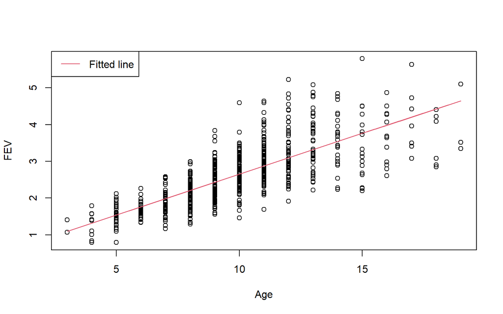

```r
plot(fev$age, fev$fev, main = "", xlab="Age", ylab="FEV")
#abline(modelResult, cex = 1.3, pch = 16, col=2)
lines(fev$age, modelResult$fitted.values, lty=1, col=2)
legend("topleft", "Fitted line", lty=1, col=2)
```

#### Checking the residuals

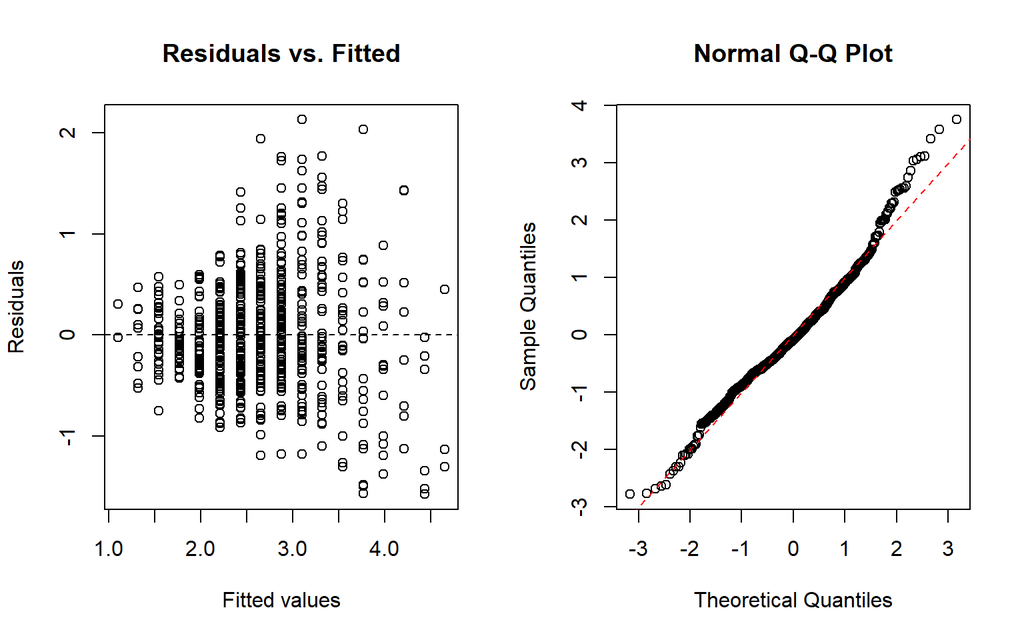

```r
par(mfrow=c(1, 2))
plot(modelResult$fitted.values, modelResult$residuals, main="Residuals vs. Fitted", xlab="Fitted values", ylab="Residuals")
abline(h=0, lty=2)

qqnorm(scale(modelResult$residuals))
abline(0,1,lty=2,col="red")
```

### Predict new data

```r
newData <- data.frame(age = c(Subject1 = 5, Subject2 = 10))
predict(modelResult, newData)
```

```
## Subject1 Subject2
## 1.541853 2.652058
```

### Visualization of confidence interval

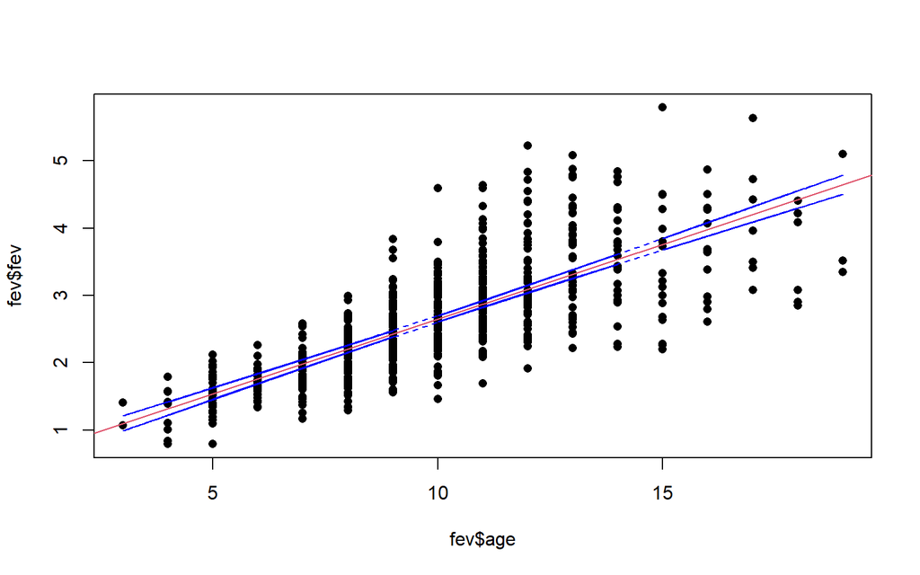

```r
preds <- predict(modelResult, data = fev, interval = 'confidence')

plot(fev$age,fev$fev,pch=16)

#add fitted regression line
abline(modelResult,col=2)
#add dashed lines for confidence bands
lines(fev$age, preds[ ,3], lty = 'dashed', col = 'blue')
lines(fev$age, preds[ ,2], lty = 'dashed', col = 'blue')
```

## Multiple linear regression

Multiple linear regression is an extension of simple linear regression used to predict an outcome based on multiple predictors.

**Question**: Are age, gender, and smoking associated with fev (lung function)?

### Data visualization

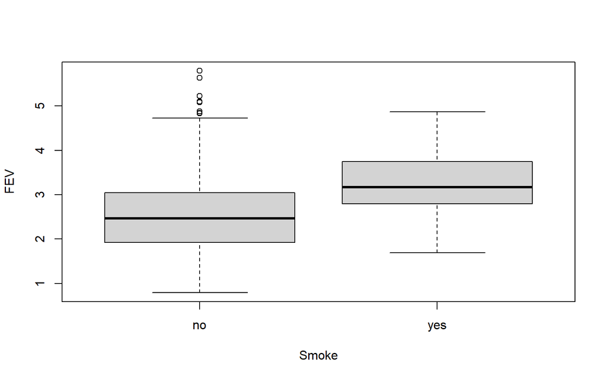

```r
boxplot(fev$fev~fev$smoke, main="", xlab="Smoke", ylab="FEV")
```

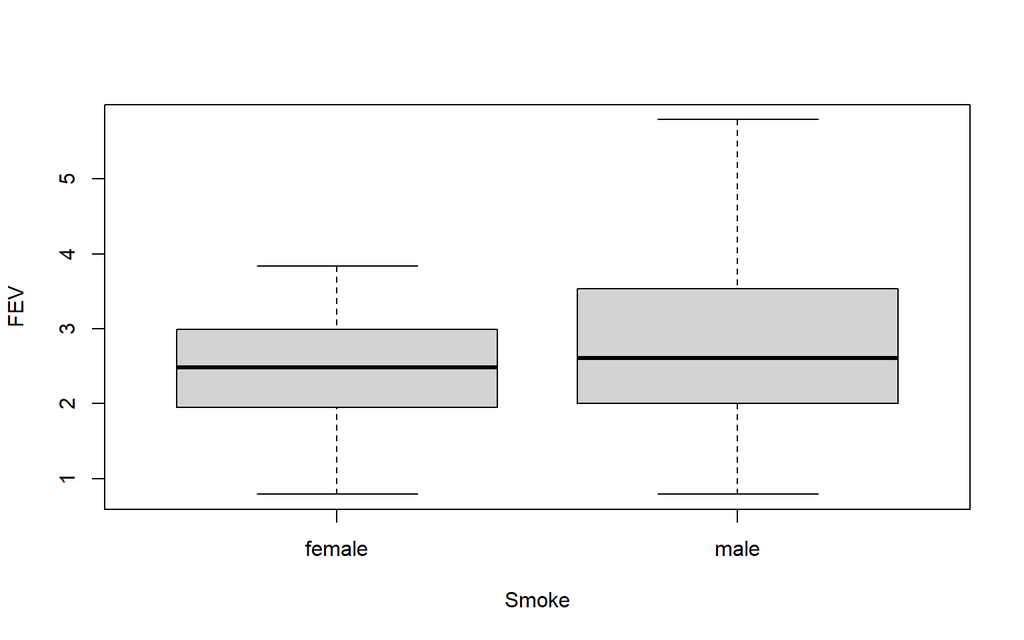

```r
boxplot(fev$fev~fev$sex, main="", xlab="Smoke", ylab="FEV")
```

### Perform a linear regression analysis

Regress `fev` on `smoke`: $fev \sim b_0 + b_1 smoke$

```r
fit1 <- lm(fev ~ smoke, data = fev)
summary(fit1)
```

```
##
## Call:
## lm(formula = fev ~ smoke, data = fev)
##
## Residuals:
##     Min      1Q  Median      3Q     Max
## -1.7751 -0.6339 -0.1021  0.4804  3.2269
##
## Coefficients:
##             Estimate Std. Error t value Pr(>|t|)
## (Intercept)  2.56614    0.03466  74.037  < 2e-16 ***
## smokeyes     0.71072    0.10994   6.464 1.99e-10 ***
## ---
## Signif. codes:  0 '***' 0.001 '**' 0.01 '*' 0.05 '.' 0.1 ' ' 1
##
## Residual standard error: 0.8412 on 652 degrees of freedom
## Multiple R-squared:  0.06023,    Adjusted R-squared:  0.05879
## F-statistic: 41.79 on 1 and 652 DF,  p-value: 1.993e-10
```

Regress `fev` on `sex`: $fev \sim b_0 + b_1 sex$

```r
fit2 <- lm(fev ~ sex, data = fev)
summary(fit2)
```

```
##
## Call:
## lm(formula = fev ~ sex, data = fev)
##
## Residuals:
##      Min       1Q   Median       3Q      Max
## -2.01645 -0.69420 -0.06367  0.58233  2.98055
##
## Coefficients:
##             Estimate Std. Error t value Pr(>|t|)
## (Intercept)  2.45117    0.04759  51.505  < 2e-16 ***
## sexmale      0.36128    0.06640   5.441  7.5e-08 ***
## ---
## Signif. codes:  0 '***' 0.001 '**' 0.01 '*' 0.05 '.' 0.1 ' ' 1
##
## Residual standard error: 0.8487 on 652 degrees of freedom
## Multiple R-squared:  0.04344,    Adjusted R-squared:  0.04197
## F-statistic: 29.61 on 1 and 652 DF,  p-value: 7.496e-08
```

### Visualization of age, gender, and smoking together

#### Age (by smoking) vs FEV

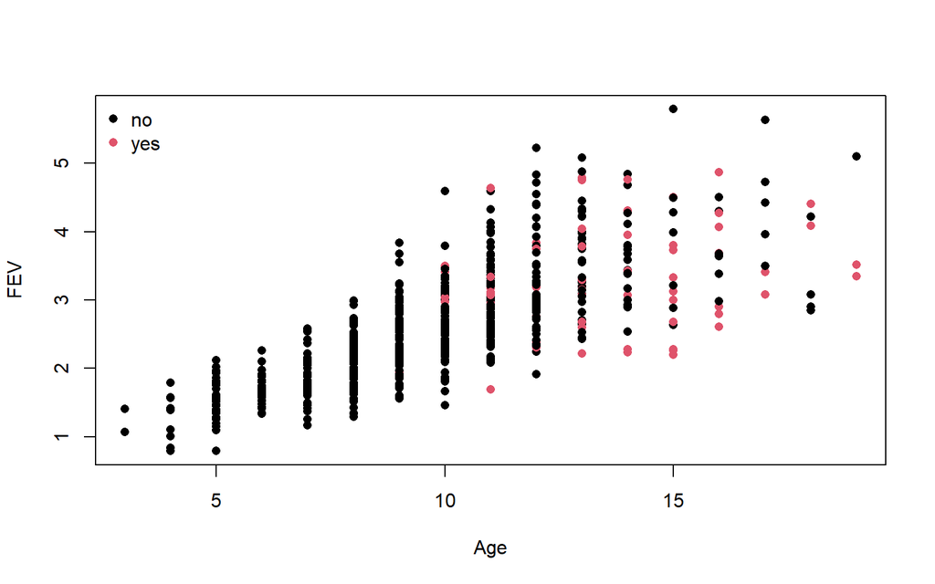

```r
plot(fev$age, fev$fev, main = "", xlab="Age", ylab="FEV",col=factor(fev$smoke),pch=16)
legend("topleft",legend=levels(factor(fev$smoke)),bty="n",col=1:2,pch=16)
```

#### Age (by gender) vs FEV

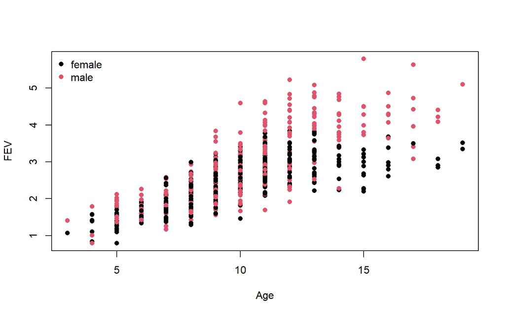

```r
plot(fev$age, fev$fev, main = "", xlab="Age", ylab="FEV",col=factor(fev$sex),pch=16)
legend("topleft",legend=levels(factor(fev$sex)),bty="n",col=1:2,pch=16)
```

### Perform a multiple linear regression analysis

```r
modelResult <- lm(fev ~ age + smoke+sex, data = fev)

summary(modelResult)
```

```
##
## Call:
## lm(formula = fev ~ age + smoke + sex, data = fev)
##
## Residuals:
##      Min       1Q   Median       3Q      Max
## -1.46707 -0.35426 -0.03811  0.32199  1.94943
##
## Coefficients:
##              Estimate Std. Error t value Pr(>|t|)
## (Intercept)  0.237771   0.080228   2.964  0.00315 **
## age          0.226794   0.007884  28.765  < 2e-16 ***
## smokeyes    -0.153974   0.077977  -1.975  0.04873 *
## sexmale      0.315273   0.042710   7.382  4.8e-13 ***
## ---
## Signif. codes:  0 '***' 0.001 '**' 0.01 '*' 0.05 '.' 0.1 ' ' 1
##
## Residual standard error: 0.5432 on 650 degrees of freedom
## Multiple R-squared:  0.6093, Adjusted R-squared:  0.6075
## F-statistic: 337.9 on 3 and 650 DF,  p-value: < 2.2e-16
```

```r
confint(modelResult)
```

```
##                   2.5 %       97.5 %
## (Intercept)  0.08023369  0.395307916
## age          0.21131214  0.242276281
## smokeyes    -0.30709050 -0.000857728
## sexmale      0.23140630  0.399140270
```

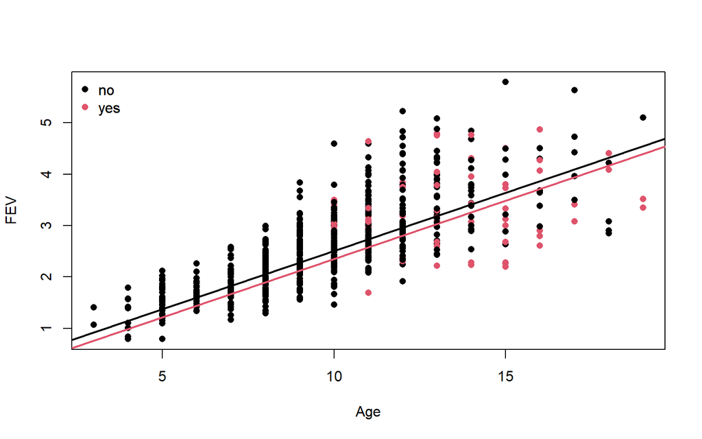

```r
plot(fev$age, fev$fev, main = "", xlab="Age", ylab="FEV",col=factor(fev$smoke),pch=16)
legend("topleft",legend=levels(factor(fev$smoke)),bty="n",col=1:2,pch=16)
abline(modelResult$coefficients["(Intercept)"],modelResult$coefficients["age"],lwd=2)
abline(modelResult$coefficients["(Intercept)"]+modelResult$coefficients["smokeyes"],modelResult$coefficients["age"],col=2,lwd=2)
legend("topleft",legend=levels(factor(fev$smoke)),bty="n",col=1:2,pch=16)
```

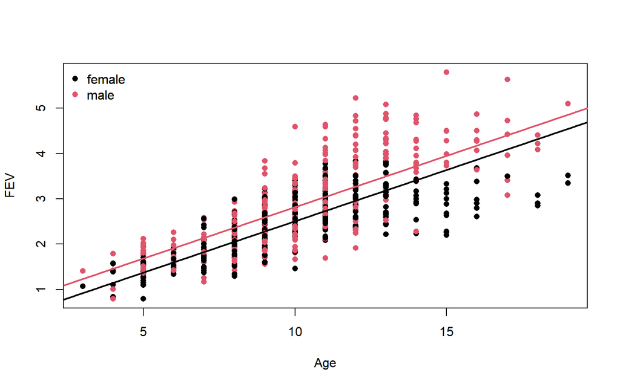

```r
plot(fev$age, fev$fev, main = "", xlab="Age", ylab="FEV",col=factor(fev$sex),pch=16)
legend("topleft",legend=levels(factor(fev$sex)),bty="n",col=1:2,pch=16)
abline(modelResult$coefficients["(Intercept)"],modelResult$coefficients["age"],lwd=2)
abline(modelResult$coefficients["(Intercept)"]+modelResult$coefficients["sexmale"],modelResult$coefficients["age"],col=2,lwd=2)
legend("topleft",legend=levels(factor(fev$sex)),bty="n",col=1:2,pch=16)
```

### Effects of variables

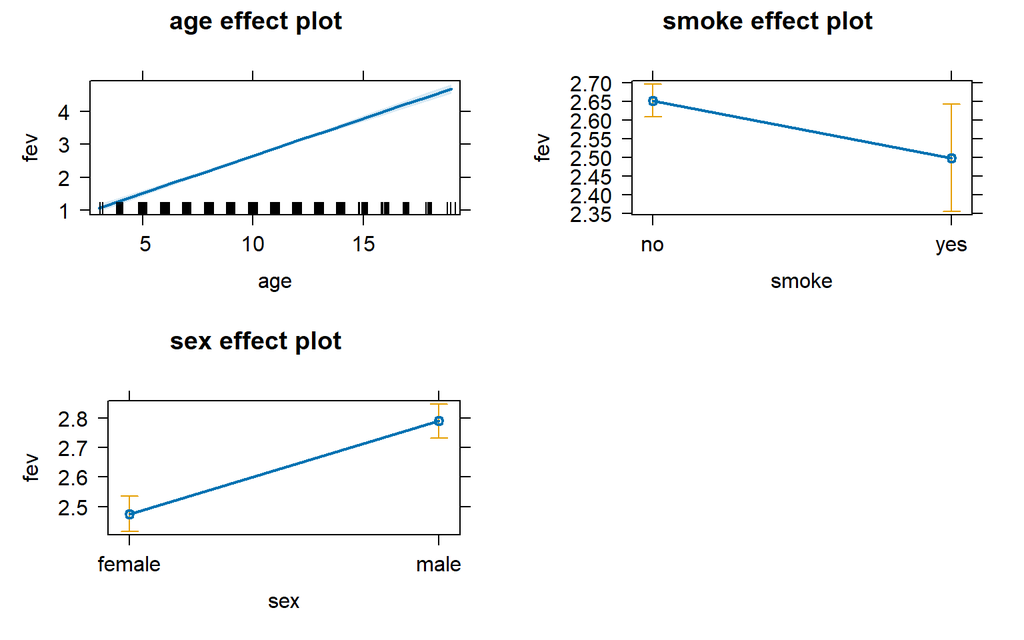

```r
library(effects)
plot(allEffects(modelResult))
```

### Multicollinearity?

Multicollinearity occurs when two or more predictor variables (X’s) in a regression model are highly correlated with each other. In other words, One predictor can be linearly predicted from another, which means They carry redundant information.

**Multicollinearity** **messes up interpretation and inference**.

```r
# Simulate data
set.seed(123)
n <- 100

# Create a base variable (e.g., "lifestyle")
lifestyle <- rnorm(n, mean = 50, sd = 10)

# Create highly correlated variables
drinking <- lifestyle + rnorm(n, 0, 2)     # highly correlated with lifestyle
smoking  <- lifestyle + rnorm(n, 0, 2)     # also highly correlated

# Outcome depends on both
disease_risk <- 0.3 * drinking + 0.3 * smoking + rnorm(n, 0, 5)

# Fit multiple linear regression
model <- lm(disease_risk ~ drinking + smoking)

# View model summary
summary(model)
```

```
##
## Call:
## lm(formula = disease_risk ~ drinking + smoking)
##
## Residuals:
##      Min       1Q   Median       3Q      Max
## -12.4571  -3.2699   0.2833   3.3518  12.6609
##
## Coefficients:
##             Estimate Std. Error t value Pr(>|t|)
## (Intercept)   1.2897     3.0116   0.428   0.6694
## drinking      0.4156     0.1977   2.102   0.0381 *
## smoking       0.1566     0.2011   0.779   0.4380
## ---
## Signif. codes:  0 '***' 0.001 '**' 0.01 '*' 0.05 '.' 0.1 ' ' 1
##
## Residual standard error: 5.23 on 97 degrees of freedom
## Multiple R-squared:  0.5038, Adjusted R-squared:  0.4936
## F-statistic: 49.25 on 2 and 97 DF,  p-value: 1.727e-15
```

```r
cor(drinking, smoking)  # should be ~0.95 or higher
```

```
## [1] 0.957672
```

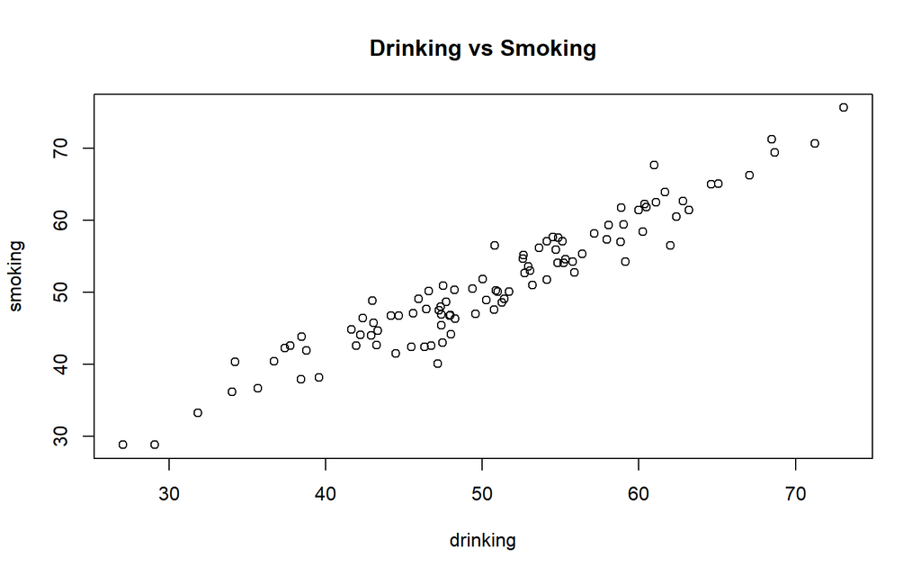

```r
plot(drinking, smoking, main = "Drinking vs Smoking")
```

```r
# Model with only drinking
model_drink <- lm(disease_risk ~ drinking)
summary(model_drink)
```

```
##
## Call:
## lm(formula = disease_risk ~ drinking)
##
## Residuals:
##      Min       1Q   Median       3Q      Max
## -12.8472  -3.2983   0.1147   3.3670  12.5419
##
## Coefficients:
##             Estimate Std. Error t value Pr(>|t|)
## (Intercept)   1.8258     2.9260   0.624    0.534
## drinking      0.5631     0.0568   9.914   <2e-16 ***
## ---
## Signif. codes:  0 '***' 0.001 '**' 0.01 '*' 0.05 '.' 0.1 ' ' 1
##
## Residual standard error: 5.22 on 98 degrees of freedom
## Multiple R-squared:  0.5007, Adjusted R-squared:  0.4956
## F-statistic: 98.29 on 1 and 98 DF,  p-value: < 2.2e-16
```

```r
# Model with only smoking
model_smoke <- lm(disease_risk ~ smoking)
summary(model_smoke)
```

```
##
## Call:
## lm(formula = disease_risk ~ smoking)
##
## Residuals:
##      Min       1Q   Median       3Q      Max
## -11.3623  -3.4797   0.3038   3.8172  13.7913
##
## Coefficients:
##             Estimate Std. Error t value Pr(>|t|)
## (Intercept)  1.64957    3.05872   0.539    0.591
## smoking      0.56153    0.05889   9.535 1.24e-15 ***
## ---
## Signif. codes:  0 '***' 0.001 '**' 0.01 '*' 0.05 '.' 0.1 ' ' 1
##
## Residual standard error: 5.321 on 98 degrees of freedom
## Multiple R-squared:  0.4812, Adjusted R-squared:  0.4759
## F-statistic: 90.91 on 1 and 98 DF,  p-value: 1.238e-15
```